# Lab 4

### 4. Use `geom_jitter` with `stat_smooth` to examine the association between dew point and wind speed by region

- Color points by region
- Make sure to deal with `NA`s
- Fit a linear regression line by region
- Describe what you observe in the graph

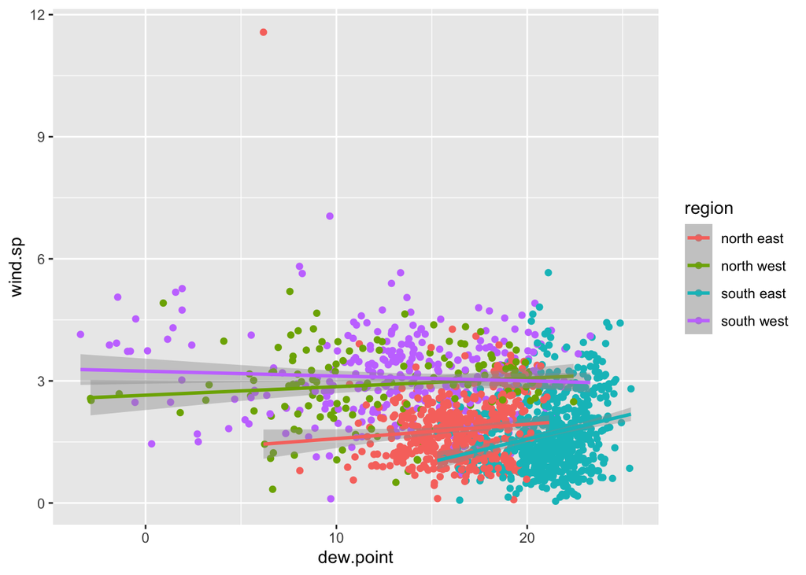

```r
met_avg |>
filter(!(region %in% NA)) |>
  ggplot(mapping = aes(x=dew.point, y=wind.sp, color=region))+
  geom_jitter() +
  stat_smooth(method=lm)
```

There is relatively good clustering of wind speeds and dew points. The southwest appears to have little to no correlation between wind speed and dew point with an almost horizontal linear regression line, meaning the wind speed is around 3 m/s in the south west, regardless of dew point. The north and south east both have slightly positive correlations between dew point and wind speed, with clustering at the higher end of the dew point. This means that as dew point increases in the east, wind speed tends to slightly increase as well. Although, there is a very large outlier in the north east with an extremely high wind speed and relatively low dew point. Finally, the north west also has a positive correlation between dew point and wind speed, with a much larger range of dew points than the eastern regions.

### 5. Use `geom_bar` to create barplots of the weather stations by elevation category colored by region

- Bars by elevation category using `position="dodge"`
- Change colors from the default. Color by region using `scale_fill_brewer` see [this](http://rstudio-pubs-static.s3.amazonaws.com/5312_98fc1aba2d5740dd849a5ab797cc2c8d.html)
- Create nice labels on the axes and add a title
- Describe what you observe in the graph
- Make sure to deal with `NA` values

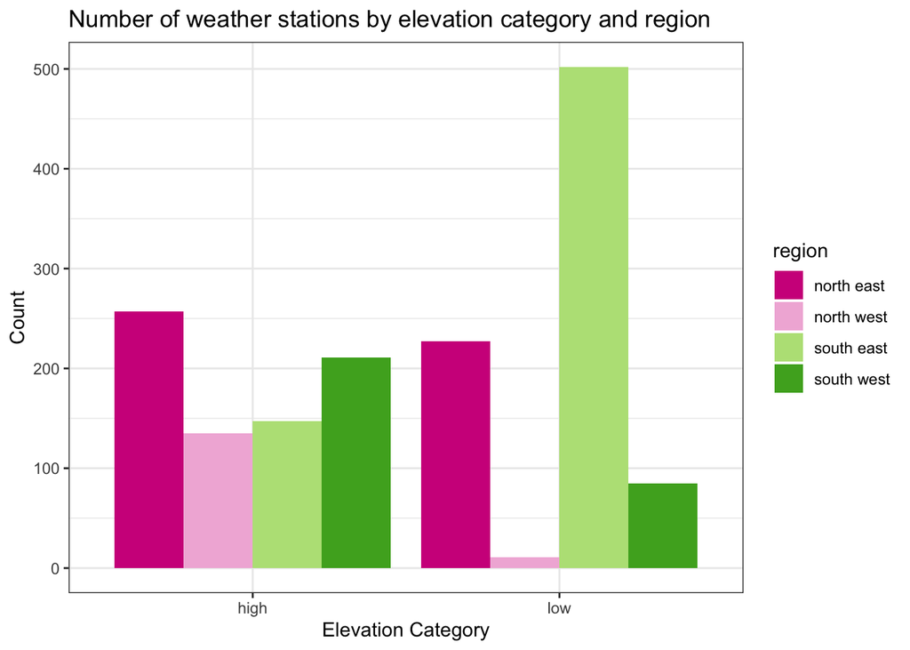

```r
met_avg |>
filter(!(region %in% NA)) |>
  ggplot()+
  geom_bar(mapping=aes(x=elev_cat,fill=region), position = "dodge")+
  scale_fill_brewer(palette = "PiYG")+
  labs(title="Number of weather stations by elevation category and region", x="Elevation Category", y= "Count")+
  theme_bw()
```

### 6. Use `stat_summary` to examine mean dew point and wind speed by region with standard deviation error bars

- Make sure to remove `NA`s
- Use `fun.data="mean_sdl"` in `stat_summary`
- Add another layer of `stats_summary` but change the geom to `"errorbar"` (see the help).
- Describe the graph and what you observe

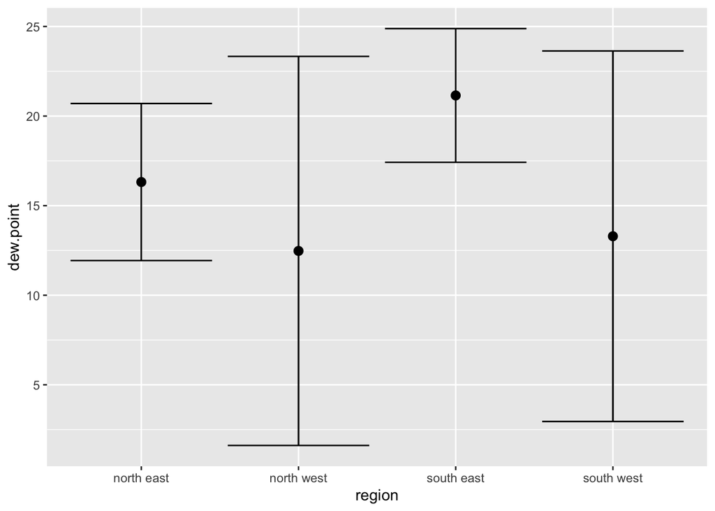

```r
met_avg |>
filter(!(region %in% NA)) |>
  ggplot(mapping=aes(x=region, y=dew.point)) +
  stat_summary(fun.data="mean_sdl", geom="errorbar") +
  stat_summary(fun.data="mean_sdl")
```

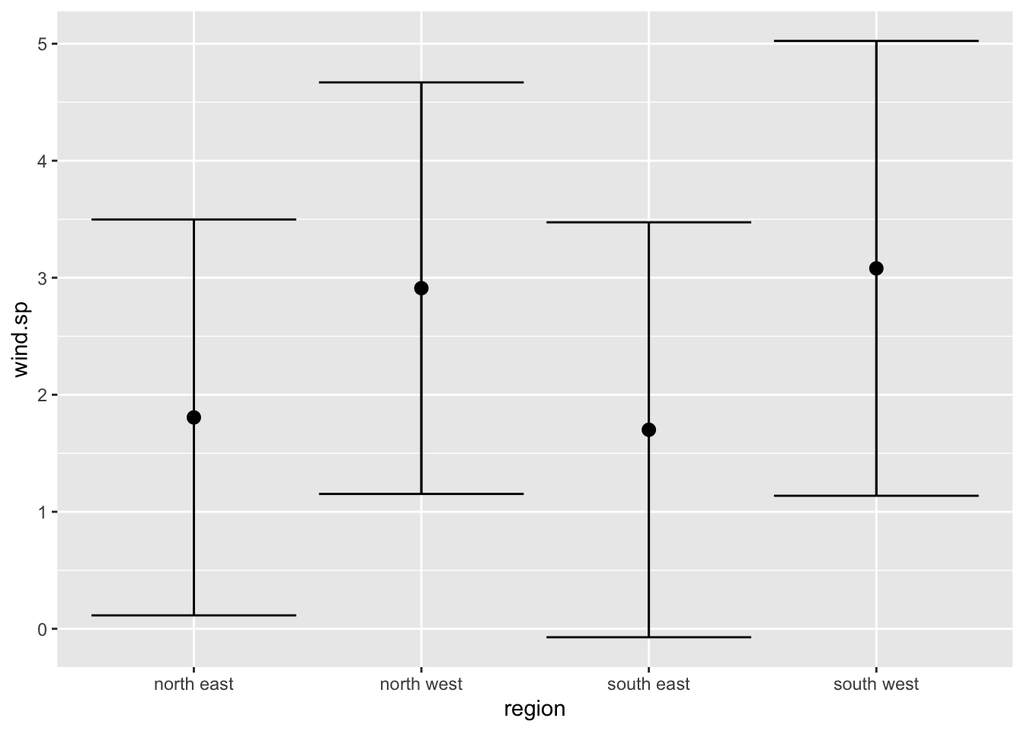

```r
met_avg |>
filter(!(region %in% NA)) |>
  ggplot(mapping=aes(x=region, y=wind.sp)) +
  stat_summary(fun.data="mean_sdl", geom="errorbar") +
  stat_summary(fun.data="mean_sdl")
```

- Dew point is highly variable and on average lower in the west compared to the east. Dew point is relatively consistent in the east and slightly higher in the south east than the north east.
- Wind speed is variable across the country and, on average, slightly higher in the west than the east.

### 7. Make a map showing the spatial trend in relative humidity in the US

- Make sure to remove `NA`s
- Use leaflet()
- Make a color palette with custom colors
- Use `addMarkers` to include the top 10 places in relative humidity (hint: this will be useful `rank(-rh) <= 10`)
- Add a legend

```r
met_avg2<-met_avg[!is.na(rh)]

# Top five
top5 <- met_avg2[rank(-rh) <= 10]

rh_pal = colorNumeric(c('blue','purple','red'), domain=met_avg2$rh)
leaflet(met_avg2) |>
  addProviderTiles('OpenStreetMap') |>
  addCircles(lat=~lat, lng=~lon, color=~rh_pal(rh), label=~paste0(round(rh,2), ' rh'), opacity=1,fillOpacity=1, radius=500) |>
  addMarkers(lat=~lat, lng=~lon, label=~paste0(round(rh,2), ' rh'), data = top5) |>
  addLegend('bottomleft',pal=rh_pal, values=met_avg2$rh, title="Relative Humidity", opacity=1)
```

[interactive chart not shown]

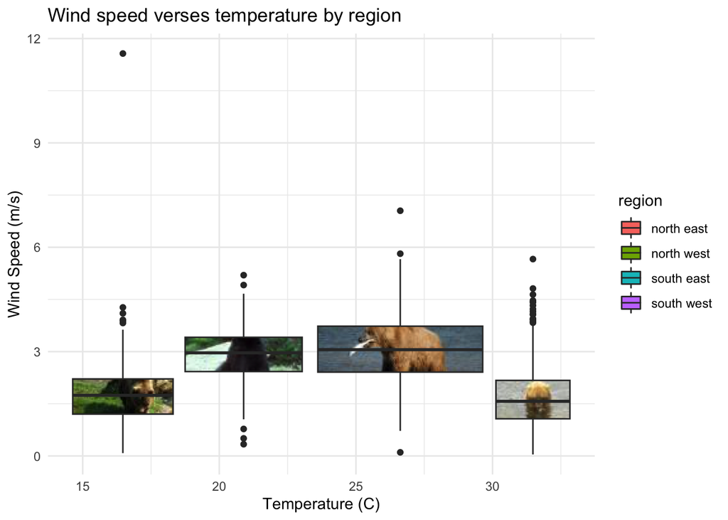

```r
## ANSWERS TO QUESTION #8
    # Make a box plot of wind speed vs temp by region using ggpattern
    ggplot(data = met_avg2) +
      geom_boxplot_pattern(mapping=aes(x=temp, y=wind.sp,fill=region), pattern = "placeholder", pattern_type = "bear") +
      labs(title="Wind speed verses temperature by region", x="Temperature (C)", y= "Wind Speed (m/s)") +
      theme_minimal()
```

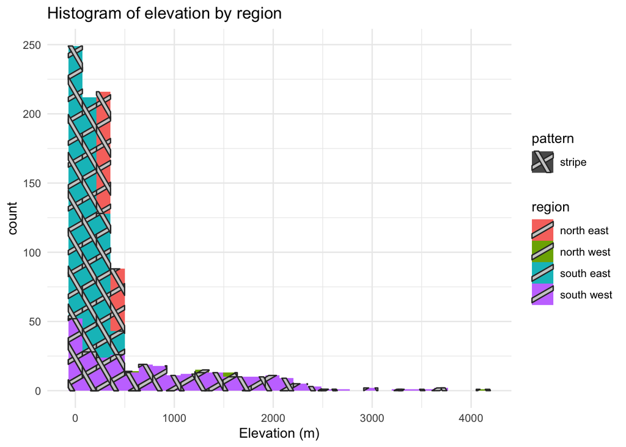

```r
    # Histogram of elevation by region using ggpattern
    ggplot(data = met_avg2) +
      geom_histogram_pattern(mapping=aes(x=elev,fill=region, pattern = "stripe"), position = "identity") +
      labs(title="Histogram of elevation by region", x="Elevation (m)") +
      theme_minimal()
```

- Describe the trend in RH across the US

  The trend of relative humidity is an increase from west to east, disregarding the coastline in west. Generally, the relative humiditiy is highest in the midwest, south, north east, and the western coastline. The relative humidity is the lowest in the sun belt and moderate in the Rocky Mountain range. 6 of the top 10 relative humidities are near the coastline in the west and Florida.

### 8. Use a ggplot extension

- Pick an extension (except cowplot) from [here](https://exts.ggplot2.tidyverse.org/gallery/) and make a plot of your choice using the met data (or met_avg)
- Might want to try examples that come with the extension first (e.g. ggtech, gganimate, ggforce)

  RStudio keeps giving me errors here, so answers are above